# hetoolkit Vignette

APEM Ltd

# Introduction

The `hetoolkit` package comprises a collection of 20 functions for assembling, processing, visualising and modelling hydro-ecological data. These are:

- `import_nrfa` for importing flow data from the National River Flow Archive (NRFA);
- `import_hde` for importing flow data from the Environment Agency (EA) Hydrology Data Explorer (HDE);
- `import_flowfiles` for importing flow data from local files;
- `import_flow` for importing flow data from a mix of the above sources;
- `import_inv` for importing macroinvertebrate sampling data from the EA Ecology and Fish Data Explorer;
- `import_env` for importing environmental base data from the EA Ecology and Fish Data Explorer;
- `import_rhs` for importing River Habitat Survey (RHS) data from the EA’s Open Data portal;
- `predict_indices` for calculating expected scores for macroinvertebrate indices using the RICT model (FBA 2020);
- `calc_flowstats` and `calc_rfrstats` for calculating summary statistics describing historical flow conditions;
- `join_he` for joining the above datasets;
- `plot_heatmap` for visualising and summarising gaps in time series data;
- `plot_hev` and `shiny_hev` for producing time series plots of biology and flow data;
- `plot_sitepca` for summarising environmental characteristics of biological sampling sites;
- `plot_rngflows` for Visualising the range of flow conditions experienced historically at a site;
- `model_cv` and `model_logocv` for performing cross-validation on linear mixed-effects models and hierarchical generalized additive models;
- `diag_lmer` for generating a variety of diagnostic plots for a mixed-effects regression (lmer) model; and
- `plot_predictions` for visualising the time series predictions from a hydro-ecological model.

This vignette illustrates a typical workflow using a selection of 20 macroinvertebrate sampling sites from the Environment Agency’s National Drought Monitoring Network (NDMN).

Although the package has been developed with macroinvertebrate data in mind, the functions can be used with any kind of biological sampling data.

# Meta-data file

To link together disparate datasets requires a look-up table of site ids. In this example, we load a table with four columns:

- *biol_site_id* = id of biology (in this case macroinvertebrate) sampling site.
- *flow_site_id* = id of paired flow gauging station.
- *flow_input* = vector specifying where to source the flow data for station (either National River Flow Archive “NRFA”, Hydrology Data Explorer “HDE”, or local files “FLOWFILES”).
- *rhs_survey_id* = id of paired River Habitat Survey (RHS) (survey id, not not site id, in case multiple surveys have been undertaken at a site).

```r
# load master file
data("master_file")

# make all columns character vectors
master_file$biol_site_id <- as.character(master_file$biol_site_id)
master_file$rhs_survey_id <- as.character(master_file$rhs_survey_id)

# filter master file for selected sites of interest
master_data <- master_file %>%
    filter(biol_site_id %in% c("34310", "34343", "34352", "55287", "55395", "55417",
        "55673", "55824", "55897", "56065", "56226", "54637", "54769", "54801", "54962",
        "80998", "56491", "54827", "77216", "52828"))

# view data
master_data
```

| biol_site_id | flow_site_id | flow_input | rhs_survey_id |
| --- | --- | --- | --- |
| 34310 | 2859TH | HDE | 39880 |
| 34343 | 4790TH | HDE | 39881 |
| 34352 | 5420TH | HDE | 39797 |
| 77216 | F3105 | HDE | 39621 |
| 52828 | 4175 | HDE | 39804 |
| 55287 | 029003 | HDE | 38660 |
| 55395 | 029001 | HDE | 38669 |
| 55417 | 030017 | HDE | 38670 |
| 55673 | 032806 | HDE | 39205 |
| 55824 | 031031 | HDE | 39707 |

[output cut: 10 more lines]

```r
# get site lists, for use with functions
biolsites <- master_data$biol_site_id
flowsites <- master_data$flow_site_id
flowinputs <- master_data$flow_input
rhssurveys <- master_data$rhs_survey_id
```

## Standardised Column Names

A number of standardised column names are used throughout the `hetoolkit` package, and throughout this vignette and its associated datasets. These include:

- *biol_site_id* = macroinvertebrate sampling site ids.
- *flow_site_id* = flow gauging station ids.
- *rhs_survey_id* = River Habitat Survey (RHS) ids (survey id, not not site id, in case multiple surveys have been undertaken at a site).
- *flow* = flow data, as downloaded using the `import_flow` function

# Prepare biology, ENV and RHS data

## Import biology data

The `import_inv` function imports macroinvertebrate sampling data from the Environment Agency’s Ecology and Fish Data Explorer. The data can either be downloaded from https://environment.data.gov.uk/ecology-fish/downloads/INV_OPEN_DATA.zip or read in from a local .csv or .rds file. The data can be optionally filtered by site ID and sample date.

Below, we use our list `biolsites` to filter the data from EDE.

```r
# Import biology data from EDE
biol_data <- import_inv(sites = biolsites, start_date = "2010-01-01", end_date = "2020-12-31")
```

```r
# view biol_data
biol_data
```

| biol_site_id | SAMPLE_ID | SAMPLE_VERSION | REPLICATE_CODE | SAMPLE_DATE | SAMPLE_TYPE | SAMPLE_TYPE_DESCRIPTION | SAMPLE_METHOD | SAMPLE_METHOD_DESCRIPTION | SAMPLE_REASON | ANALYSIS_ID | DATE_OF_ANALYSIS | ANALYSIS_TYPE | ANALYSIS_TYPE_DESCRIPTION | ANALYSIS_METHOD | ANALYSIS_METHOD_DESCRIPTION | BMWP_N_TAXA | BMWP_TOTAL | BMWP_ASPT | CCI_N_TAXA | CCI_CS_TOTAL | CCI_ASPT | CSmax_CoS | BMWP_CoS | CCI_CoS | CCI | DEHLI_N_TAXA | DIS_TOTAL | DEHLI | EPSI_ML_S_GRP | … |
| --- | --- | --- | --- | --- | --- | --- | --- | --- | --- | --- | --- | --- | --- | --- | --- | --- | --- | --- | --- | --- | --- | --- | --- | --- | --- | --- | --- | --- | --- | --- |
| 56065 | 605567 | 1 | NA | 2010-03-16 | SP | FRESHWATER: INVERTEBRATE All macroinvertebrate samples | S3PO | 3-MIN POND NET (BT001): 3-min active sampling, 1-min hand search as per BT001 | National Monitoring | 598054 | 2010-03-17 | LABP | LABORATORY PRIMARY: Analysed in laboratory by primary analyst | ANLA | LOG ABUNDANCE: Estimate of the log abundance (scale as BT001) | 26 | 123 | 4.73 | 29 | 40 | 1.38 | 3 | 5 | 5 | 6.90 | 23 | 101 | 4.39 | 11.75 | … |
| 56065 | 611126 | 1 | NA | 2010-07-28 | SP | FRESHWATER: INVERTEBRATE All macroinvertebrate samples | S3PO | 3-MIN POND NET (BT001): 3-min active sampling, 1-min hand search as per BT001 | National Monitoring | 602074 | 2010-07-29 | LABP | LABORATORY PRIMARY: Analysed in laboratory by primary analyst | ANLA | LOG ABUNDANCE: Estimate of the log abundance (scale as BT001) | 27 | 135 | 5.00 | 27 | 41 | 1.52 | 3 | 5 | 5 | 7.59 | 21 | 97 | 4.62 | 11.00 | … |
| 56065 | 614704 | 1 | NA | 2010-10-12 | SP | FRESHWATER: INVERTEBRATE All macroinvertebrate samples | S3PO | 3-MIN POND NET (BT001): 3-min active sampling, 1-min hand search as per BT001 | National Monitoring | 608877 | 2011-02-01 | LABP | LABORATORY PRIMARY: Analysed in laboratory by primary analyst | ANLA | LOG ABUNDANCE: Estimate of the log abundance (scale as BT001) | 36 | 183 | 5.08 | 41 | 65 | 1.59 | 5 | 7 | 7 | 11.10 | 27 | 127 | 4.70 | 16.38 | … |
| 56065 | 621146 | 1 | NA | 2011-03-29 | SP | FRESHWATER: INVERTEBRATE All macroinvertebrate samples | S3PO | 3-MIN POND NET (BT001): 3-min active sampling, 1-min hand search as per BT001 | National Monitoring | 613608 | 2011-05-11 | LABP | LABORATORY PRIMARY: Analysed in laboratory by primary analyst | ANLA | LOG ABUNDANCE: Estimate of the log abundance (scale as BT001) | 27 | 133 | 4.93 | 33 | 45 | 1.36 | 3 | 5 | 5 | 6.82 | 22 | 96 | 4.36 | 13.13 | … |
| 56065 | 625474 | 1 | NA | 2011-06-14 | SP | FRESHWATER: INVERTEBRATE All macroinvertebrate samples | S3PO | 3-MIN POND NET (BT001): 3-min active sampling, 1-min hand search as per BT001 | National Monitoring | 615050 | 2011-06-15 | LABP | LABORATORY PRIMARY: Analysed in laboratory by primary analyst | ANLA | LOG ABUNDANCE: Estimate of the log abundance (scale as BT001) | 22 | 105 | 4.77 | 20 | 33 | 1.65 | 5 | 5 | 5 | 8.25 | 17 | 77 | 4.53 | 9.88 | … |
| 56065 | 627625 | 1 | NA | 2011-08-06 | SP | FRESHWATER: INVERTEBRATE All macroinvertebrate samples | S3PO | 3-MIN POND NET (BT001): 3-min active sampling, 1-min hand search as per BT001 | National Monitoring | 617756 | 2011-08-15 | LABP | LABORATORY PRIMARY: Analysed in laboratory by primary analyst | ANLA | LOG ABUNDANCE: Estimate of the log abundance (scale as BT001) | 26 | 125 | 4.81 | 28 | 46 | 1.64 | 5 | 5 | 5 | 8.21 | 21 | 93 | 4.43 | 6.50 | … |
| 56065 | 630894 | 1 | NA | 2011-10-12 | SP | FRESHWATER: INVERTEBRATE All macroinvertebrate samples | S3PO | 3-MIN POND NET (BT001): 3-min active sampling, 1-min hand search as per BT001 | National Monitoring | 619856 | 2011-10-14 | LABP | LABORATORY PRIMARY: Analysed in laboratory by primary analyst | ANLA | LOG ABUNDANCE: Estimate of the log abundance (scale as BT001) | 24 | 115 | 4.79 | 29 | 48 | 1.66 | 5 | 5 | 5 | 8.28 | 20 | 90 | 4.50 | 10.00 | … |
| 56065 | 633498 | 1 | NA | 2011-12-09 | SP | FRESHWATER: INVERTEBRATE All macroinvertebrate samples | S3PO | 3-MIN POND NET (BT001): 3-min active sampling, 1-min hand search as per BT001 | National Monitoring | 622242 | 2011-12-14 | LABP | LABORATORY PRIMARY: Analysed in laboratory by primary analyst | ANLA | LOG ABUNDANCE: Estimate of the log abundance (scale as BT001) | 25 | 133 | 5.32 | 28 | 43 | 1.54 | 5 | 5 | 5 | 7.68 | 21 | 91 | 4.33 | 13.75 | … |
| 56065 | 634677 | 1 | NA | 2012-02-08 | SP | FRESHWATER: INVERTEBRATE All macroinvertebrate samples | S3PO | 3-MIN POND NET (BT001): 3-min active sampling, 1-min hand search as per BT001 | National Monitoring | 625075 | 2012-02-14 | LABP | LABORATORY PRIMARY: Analysed in laboratory by primary analyst | ANCA | COLD ACID: Cold acid (digestion method for diatoms) | 26 | 127 | 4.88 | 24 | 30 | 1.25 | 1 | 5 | 5 | 6.25 | 19 | 93 | 4.89 | 8.38 | … |
| 56065 | 635806 | 1 | NA | 2012-04-12 | SP | FRESHWATER: INVERTEBRATE All macroinvertebrate samples | S3PO | 3-MIN POND NET (BT001): 3-min active sampling, 1-min hand search as per BT001 | National Monitoring | 626117 | 2012-04-13 | LABP | LABORATORY PRIMARY: Analysed in laboratory by primary analyst | ANLA | LOG ABUNDANCE: Estimate of the log abundance (scale as BT001) | 23 | 114 | 4.96 | 23 | 33 | 1.43 | 3 | 5 | 5 | 7.17 | 18 | 85 | 4.72 | 8.76 | … |

[output cut: 517 more lines]

## Optional: Join additional biology data

If the user has additional biology data in a separate Excel file, it is possible to append this to the EDE download. The additional data must have the same column names as the EDE download file.

```r
# bind 2 biology data sets - one from EDE and one local file

# drop any unwanted variables/columns from the EDE download file
drops_bio <- c("SAMPLE_VERSION", "REPLICATE_CODE", "SAMPLE_TYPE", "SAMPLE_METHOD",
    "ANALYSIS_TYPE", "ANALYSIS_METHOD", "IS_THIRD_PARTY_DATA", "WATERBODY_TYPE")

# drop unwanted variables
biol_data2 <- biol_data[, !(names(biol_data) %in% drops_bio)]

# read in additional biology data in csv format
biol_data_excel <- read.csv("data/biol_data_join.csv")

# format columns
biol_data_excel <- biol_data_excel %>%
    dplyr::mutate(biol_site_id = as.character(biol_site_id))

# convert to tibble format
biol_data_excel <- as_tibble(biol_data_excel)

# bind datasets
biol_data_final <- rbind(biol_data2, biol_data_excel)
```

## Import environmental data

The `import_env` function allows the user to download environmental base data from the Environment Agency’s Ecology and Fish Data Explorer.

The function either:

- downloads environmental data data from https://environment.data.gov.uk/ecology-fish/downloads/INV_OPEN_DATA.zip
- **or** imports it from a local .csv or .rds file

Data can be optionally filtered by site ID.

When saving, the name of rds file is hard-wired to: INV_OPEN_DATA_SITES_ALL.rds.

If saving prior to filtering, the name of the filtered rds file is hard-wired to: INV_OPEN_DATA_SITE_F.rds.

Below, we use our list `biolsites` to filter the data from EDE.

```r
# Import biology data from EDE
env_data <- import_env(sites = biolsites)
```

```r
# view env_data
env_data
```

| AGENCY_AREA | CATCHMENT | WATERBODY_TYPE | WATERBODY_TYPE_DESCRIPTION | WATER_BODY | biol_site_id | SITE_VERSION | NGR_PREFIX | EASTING | NORTHING | NGR_10_FIG | FULL_EASTING | FULL_NORTHING | WFD_WATERBODY_ID | ALTITUDE | SLOPE | DIST_FROM_SOURCE | DISCHARGE | WIDTH | DEPTH | BOULDERS_COBBLES | PEBBLES_GRAVEL | SAND | SILT_CLAY | ALKALINITY | CONDUCTIVITY | TOTAL_HARDNESS | CALCIUM | BASE_DATA_DATE | MIN_SAMPLE_DATE | … |
| --- | --- | --- | --- | --- | --- | --- | --- | --- | --- | --- | --- | --- | --- | --- | --- | --- | --- | --- | --- | --- | --- | --- | --- | --- | --- | --- | --- | --- | --- | --- |
| ANGLIAN - NORTHERN | EAST LINCS | WBRV | RIVER: Natural/semi-natural flowing fresh watercourse | WAITHE BECK | 55395 | 1 | TA | 25247 | 01658 | TA2524701658 | 525247 | 401658 | GB104029062100 | 15 | 2.5 | 20.05 | 1 | 3.0 | 22.67 | 30 | 27 | 32 | 12 | 193.3 | NA | NA | NA | 1995-01-01 | 1986-09-09 | … |
| ANGLIAN - EASTERN | WENSUM | WBRV | RIVER: Natural/semi-natural flowing fresh watercourse | WENSUM | 54962 | 1 | TG | 10735 | 18725 | TG1073518725 | 610735 | 318725 | GB105034055881 | 10 | 0.8 | 50.50 | 5 | 10.7 | 26.00 | 6 | 45 | 42 | 6 | 246.0 | NA | NA | NA | 1995-01-01 | 1990-05-10 | … |
| ANGLIAN - NORTHERN | CENTRAL LINCS | WBRV | RIVER: Natural/semi-natural flowing fresh watercourse | UPPER WITHAM | 55417 | 1 | SK | 92752 | 26961 | SK9275226961 | 492752 | 326961 | GB105030051570 | 80 | 2.4 | 13.00 | 1 | 4.7 | 17.00 | 50 | 17 | 19 | 14 | 204.8 | NA | NA | NA | 1995-01-01 | 1986-04-22 | … |
| THAMES - NORTH EAST | RODING | WBRV | RIVER: Natural/semi-natural flowing fresh watercourse | RODING | 34352 | 1 | TL | 56104 | 04058 | TL5610404058 | 556104 | 204058 | GB106037033500 | 41 | 1.3 | 28.73 | 1 | 4.0 | 18.33 | 3 | 52 | 18 | 27 | 250.0 | NA | NA | NA | 1995-01-01 | 1979-08-06 | … |
| ANGLIAN - EASTERN | COLNE (ANGLIAN) | WBRV | RIVER: Natural/semi-natural flowing fresh watercourse | COLNE | 54637 | 1 | TL | 97270 | 25650 | TL9727025650 | 597270 | 225650 | GB105037041330 | 10 | 0.3 | 38.50 | 3 | 7.0 | 15.33 | 5 | 60 | 25 | 10 | 228.0 | NA | NA | NA | 1995-01-01 | 1986-11-04 | … |
| ANGLIAN - NORTHERN | EAST LINCS | WBRV | RIVER: Natural/semi-natural flowing fresh watercourse | LUD | 55287 | 1 | TF | 32100 | 87200 | TF3210087200 | 532100 | 387200 | GB104029061990 | 25 | 4.9 | 7.25 | 2 | 5.3 | 12.67 | 17 | 27 | 30 | 27 | 178.1 | NA | NA | NA | 1995-01-01 | 1980-10-27 | … |
| ANGLIAN - EASTERN | ALDE AND ORE | WBRV | RIVER: Natural/semi-natural flowing fresh watercourse | ALDE | 54769 | 1 | TM | 37500 | 58150 | TM3750058150 | 637500 | 258150 | GB105035045950 | 5 | 0.3 | 22.00 | 2 | 5.0 | 16.00 | 22 | 38 | 23 | 17 | 281.4 | NA | NA | NA | 1995-01-01 | 1995-03-27 | … |
| ANGLIAN - CENTRAL | UPPER OUSE | WBRV | RIVER: Natural/semi-natural flowing fresh watercourse | OUSE (UPPER) | 56491 | 1 | SP | 65228 | 34068 | SP6522834068 | 465228 | 234068 | GB105033037860 | 90 | 1.0 | 18.00 | 3 | 4.7 | 30.00 | 5 | 82 | 0 | 13 | 227.1 | NA | NA | NA | 1995-01-01 | 1995-03-06 | … |
| THAMES - NORTH EAST | MIMRAM | WBRV | RIVER: Natural/semi-natural flowing fresh watercourse | MIMRAM | 34343 | 1 | TL | 27886 | 13403 | TL2788613403 | 527886 | 213403 | GB106038033270 | 49 | 3.0 | 18.19 | 2 | 9.0 | 26.33 | 2 | 77 | 11 | 10 | 260.0 | NA | NA | NA | 1995-01-01 | 1980-01-07 | … |
| NORTH EAST - YORKSHIRE | HULL | WBRV | RIVER: Natural/semi-natural flowing fresh watercourse | HULL/WEST BECK | 77216 | 2 | TA | 06437 | 55920 | TA0643755920 | 506437 | 455920 | GB104026067080 | 5 | 0.1 | 14.70 | 4 | 12.0 | 105.00 | NA | 75 | 10 | 15 | 187.3 | NA | NA | NA | 2012-06-01 | 2000-05-31 | … |

[output cut: 10 more lines]

## Optional: Map biology sites

### Get data

First we download zipped shapefiles for our basemap, and load them in as sf objects. The zipped shapefiles are left in the users project / working directory. The England map is of EA public facing area boundaries. The additional map covering the Wales coastline comes from the ESRC UK Data Service.

```r
## get shapefile for EA areas
# download('https://environment.data.gov.uk/UserDownloads/interactive/d733# 68b35bb74163a384d3d29e479c0d75644/EA_AdminBoundEAandNEpublicFaceAreas_SH# P_Full.zip', destfile = # 'EA_AdminBoundEAandNEpublicFaceAreas_SHP_Full.zip')

## get Wales coastline, just because map looks silly without it
# download('https://borders.ukdataservice.ac.uk/ukborders/easy_download/pr# ebuilt/shape/Wales_ol_2001.zip', destfile = 'Wales_ol_2001.zip')

## load in the shapefiles to R objects and remove seaward parts
# EA.areas <- read_sf('/vsizip/EA_AdminBoundEAandNEpublicFaceAreas_SHP_Ful# l.zip/data/Administrative_Boundaries_Environment_Agency_and_Natural_Engl# and_Public_Face_Areas.shp')
# wales <- read_sf('/vsizip/Wales_ol_2001.zip')
# EA.areas.land <- EA.areas %>% dplyr::filter(seaward == 'No')
```

### Data processing

We use the environmental base data that we have downloaded from the Ecology and Fish Data Explorer using `import_env`, this gives us their NGRs. We translate the NGRs to full eastings / northings and use this to turn the base data frame into a sf point object for plotting.

```r
## translate NGRs to full easting / northing
# temp.eastnorths <- osg_parse(env_data$NGR_10_FIG, coord_system = "BNG") # %>% as_tibble()

## make an sf point object to plot with geom_sf but retain the easting and northing column required by geom_text_repel
# env_sf <- st_as_sf(bind_cols(temp.eastnorths, env_data), coords =  c("easting", "northing"), crs = 27700, remove = FALSE)
```

### Create the map

Finally we use ggplot with geom_sf() to plot the points and ggrepel::geom_text_repel() to plot the labels.

```r
# basemap <- ggplot() + geom_sf(mapping = aes(), data = EA.areas.land) +
#   geom_sf(mapping = aes(), data = wales)

# basemap + geom_sf(data = env_sf, col = "blue", size = 1.5) +
#   geom_text_repel(data = env_sf, aes(x=easting, y=northing, label = biol_site_id), col = "blue") +
#   coord_sf(datum = sf::st_crs(27700))
```

## Optional: Join additional environmental data

Any additional environmental data in a separate Excel file can be appended to the EDE download. The additional data must have the same column names as the EDE download file.

```r
# bind 2 env data sets - one from EDE and one local file

# drop any unwanted variables/columns from the download file
drops_env <- c("AGENCY_AREA", "CATCHMENT", "WATERBODY_TYPE", "WATERBODY_TYPE_DESCRIPTION",
    "SITE_VERSION", "NGR_10_FIG", "FULL_EASTING", "FULL_NORTHING", "BASE_DATA_DATE",
    "MIN_SAMPLE_DATE", "MAX_SAMPLE_DATE", "COUNT_OF_SAMPLES", "ECN_SITE", "INV",
    "ECN_SITE_INV")

# drop unwanted variables
env_data <- env_data[, !(names(env_data) %in% drops_env)]

# read-in environmental data in excel format
env_data_excel <- read_excel("data/Env_Additonal_Sites.xlsx")

# format columns
env_data_excel <- env_data_excel %>%
    dplyr::mutate(biol_site_id = as.character(biol_site_id), WATER_BODY = as.character(WATER_BODY),
        NGR_PREFIX = as.character(NGR_PREFIX), EASTING = as.character(EASTING), NORTHING = as.character(NORTHING),
        WFD_WATERBODY_ID = as.character(WFD_WATERBODY_ID))

# convert to tibble format
env_data_excel <- as.tibble(env_data_excel)

# join datasets
env_data_final <- rbind(env_data, env_data_excel)
```

## Import RHS data

The `import_rhs` function allows the user to download River Habitat Survey (RHS) data from Open Data.

The function either:

- downloads RHS data from Open Data, https://environment.data.gov.uk/portalstg/sharing/rest/content/items/b82d3ef3750d49f6917fff02b9341d68/data
- **or** imports it from a local xlsx or rds file.

Data can be optionally filtered by survey ID.

Downloaded raw data files (in .zip format) will be automatically removed from the working directory following completed execution of the function.

Below, we use our list `rhssurveys` to filter the downloaded data.

To enable the RHS data to be joined to the biology and flow data at a later stage, it is necessary to rename the `Survey ID` column to `rhs_survey_id`.

```r
# import RHS data from Open Data
rhs_data <- import_rhs(surveys = rhssurveys)

# rename Survey.ID as rhs_survey_id
rhs_data <- rhs_data %>%
    dplyr::rename(rhs_survey_id = Survey.ID)
```

If required, unwanted variables can be dropped from the dataset.

```r
# select Columns to keep
rhs_keep <- c("rhs_survey_id", "Hms.Poaching.Sub.Score", "Hms.Rsctned.Bnk.Bed.Sub.Score",
    "HMS.Score")

# select columns of interest
rhs_data <- rhs_data[, (names(rhs_data) %in% rhs_keep)]
```

```r
# view rhs_data
rhs_data
```

| rhs_survey_id | HMS.Score | Hms.Poaching.Sub.Score | Hms.Rsctned.Bnk.Bed.Sub.Score |
| --- | --- | --- | --- |
| 38660 | 1305 | 0 | 80 |
| 38669 | 3175 | 0 | 2000 |
| 38670 | 525 | 10 | 0 |
| 38952 | 3140 | 0 | 2280 |
| 39205 | 3420 | 0 | 2520 |
| 39310 | 3810 | 0 | 2200 |
| 39560 | 240 | 0 | 0 |
| 39574 | 780 | 0 | 760 |
| 39611 | 2480 | 0 | 2200 |
| 39612 | 2600 | 50 | 2000 |

[output cut: 10 more lines]

## Predict expected indices

The `predict_indices` function mirrors the functionality of the RICT model available on the MS Azure platform (https://gallery.azure.ai/Experiment/RICT-package-2). Specifically, it uses the environmental data downloaded from EDE to generate expected scores under minimally impacted reference conditions for 80 indices, plus probabilities for RIVPACS end-groups. No classification is undertaken.

All data validation and transformation (conversion) are done within `predict_indices` using functions predefined in HelperFunctionsv1.R. Similarly, predictions are made using PredictionfunctionsV2.R.

To run, the following columns containing substrate composition data must not contain NAs, and must total to 100 for every site:

- BOULDERS_COBBLES
- PEBBLES_GRAVEL
- SAND
- SILT_CLAY

The code below demonstrates the how to summarise whether these columns contain NAs, and how to replace NAs as required.

```r
# check substrate variables for presence of NAs
env_data %>%
    select(BOULDERS_COBBLES, PEBBLES_GRAVEL, SAND, SILT_CLAY) %>%
    summarise_all(funs(sum(is.na(.))))
```

| BOULDERS_COBBLES | PEBBLES_GRAVEL | SAND | SILT_CLAY |
| --- | --- | --- | --- |
| 1 | 0 | 0 | 0 |

```r
# replace NAs, if required
env_data$BOULDERS_COBBLES[is.na(env_data$BOULDERS_COBBLES)] <- 0
```

Now that the substrate data is complete, the expected scores can be generated.

```r
# run predictions
predict_data <- predict_indices(env_data = env_data)

# view predict_data
predict_data
```

| biol_site_id | LATITUDE | LONGITUDE | LOG.ALTITUDE | LOG.DISTANCE.FROM.SOURCE | LOG.WIDTH | LOG.DEPTH | MEAN.SUBSTRATUM | DISCHARGE.CATEGORY | ALKALINITY | LOG.ALKALINITY | LOG.SLOPE | MEAN.AIR.TEMP | AIR.TEMP.RANGE | p1 | p2 | p3 | p4 | p5 | p6 | p7 | p8 | p9 | p10 | p11 | p12 | p13 | p14 | p15 | p16 | … |
| --- | --- | --- | --- | --- | --- | --- | --- | --- | --- | --- | --- | --- | --- | --- | --- | --- | --- | --- | --- | --- | --- | --- | --- | --- | --- | --- | --- | --- | --- | --- |
| 55395 | 53.95019 | -0.17295254 | 1.176091 | 1.3021144 | 0.4771213 | 1.355452 | -1.5866337 | 1 | 193.3 | 2.286232 | 0.39794001 | 9.588836 | 12.74009 | 3.880572e-16 | 5.816184e-12 | 2.100096e-19 | 1.365718e-12 | 4.322092e-18 | 3.689514e-13 | 1.923634e-11 | 2.964294e-12 | 8.048567e-12 | 2.261453e-13 | 2.400587e-12 | 1.314942e-09 | 2.557745e-12 | 5.728054e-14 | 1.207989e-15 | 5.824470e-10 | … |
| 54962 | 52.62014 | 1.10088850 | 1.000000 | 1.7032914 | 1.0293838 | 1.414973 | -0.6136364 | 5 | 246.0 | 2.390935 | -0.09691001 | 9.784900 | 13.35198 | 3.899867e-20 | 4.499226e-17 | 1.490955e-25 | 3.231490e-18 | 1.005651e-21 | 5.531160e-18 | 1.195089e-17 | 5.362055e-18 | 3.513369e-16 | 1.613268e-18 | 2.308416e-14 | 4.444098e-13 | 2.859400e-17 | 6.599664e-19 | 5.307863e-19 | 8.753993e-16 | … |
| 55417 | 52.83301 | -0.66552343 | 1.903090 | 1.1139434 | 0.6720979 | 1.230449 | -2.9275000 | 1 | 204.8 | 2.311330 | 0.38021124 | 9.779701 | 13.12142 | 1.681976e-18 | 2.867052e-12 | 3.387586e-18 | 8.539777e-12 | 1.954690e-16 | 6.213398e-12 | 1.222509e-11 | 2.240390e-10 | 1.519712e-09 | 1.133682e-11 | 6.882097e-10 | 7.302886e-08 | 2.154878e-11 | 1.527009e-11 | 5.022322e-13 | 5.852157e-08 | … |
| 34352 | 52.22678 | 0.19474338 | 1.612784 | 1.4583356 | 0.6020600 | 1.263162 | 0.5975000 | 1 | 250.0 | 2.397940 | 0.11394335 | 10.082827 | 13.45014 | 5.865760e-23 | 2.023440e-17 | 1.574583e-24 | 3.257656e-17 | 6.985414e-22 | 6.657780e-18 | 4.171093e-17 | 2.513575e-17 | 2.351106e-16 | 4.398036e-19 | 5.420947e-16 | 9.101689e-14 | 8.913818e-18 | 1.443733e-18 | 1.012540e-19 | 1.355337e-14 | … |
| 54637 | 52.31322 | 0.78590632 | 1.000000 | 1.5854607 | 0.8450980 | 1.185542 | -1.0375000 | 3 | 228.0 | 2.357935 | -0.52287875 | 10.019312 | 13.54083 | 1.515883e-20 | 1.812965e-18 | 8.113424e-27 | 1.562029e-17 | 4.647538e-23 | 6.387385e-18 | 1.141434e-16 | 5.836326e-19 | 1.552527e-16 | 4.425346e-20 | 6.851342e-16 | 8.110625e-14 | 5.698195e-18 | 1.774250e-20 | 4.459895e-21 | 1.461426e-16 | … |
| 55287 | 52.77095 | -0.07447446 | 1.397940 | 0.8603380 | 0.7242759 | 1.102777 | 0.5594059 | 2 | 178.1 | 2.250664 | 0.69019608 | 9.499105 | 12.88179 | 8.855058e-16 | 1.084383e-09 | 8.757894e-18 | 2.667455e-12 | 2.280879e-16 | 1.832639e-12 | 1.576602e-11 | 1.299057e-09 | 1.104985e-09 | 4.514011e-11 | 2.574934e-09 | 9.485330e-08 | 2.266067e-10 | 5.692691e-11 | 2.895766e-11 | 8.339093e-08 | … |
| 54769 | 52.32486 | 1.37375477 | 0.698970 | 1.3424227 | 0.6989700 | 1.204120 | -1.1200000 | 2 | 281.4 | 2.449324 | -0.52287875 | 10.079635 | 13.45073 | 3.279170e-21 | 3.059767e-20 | 3.362033e-28 | 1.758330e-19 | 6.165148e-25 | 7.129100e-21 | 3.857972e-19 | 1.076088e-21 | 1.699758e-19 | 3.457766e-23 | 4.544460e-20 | 1.868761e-17 | 5.591623e-21 | 6.763721e-24 | 2.785748e-24 | 7.978492e-20 | … |
| 56491 | 52.16302 | -1.12425248 | 1.954243 | 1.2552725 | 0.6720979 | 1.477121 | -2.0125000 | 3 | 227.1 | 2.356217 | 0.00000000 | 10.029027 | 13.19915 | 7.586942e-23 | 7.729969e-15 | 4.980440e-21 | 1.808352e-14 | 5.598868e-18 | 9.536422e-14 | 2.076558e-13 | 3.279660e-12 | 1.202769e-10 | 2.731551e-13 | 6.281527e-11 | 3.423692e-09 | 2.473184e-13 | 1.394803e-13 | 4.598721e-15 | 4.389377e-10 | … |
| 34343 | 52.38689 | -0.23818249 | 1.690196 | 1.2598327 | 0.9542425 | 1.420451 | -1.6375000 | 2 | 260.0 | 2.414973 | 0.47712125 | 10.056017 | 13.34162 | 7.870222e-23 | 6.189838e-16 | 4.142523e-21 | 2.926100e-15 | 3.317403e-19 | 2.118808e-15 | 2.704558e-15 | 1.602523e-14 | 5.430628e-13 | 1.669741e-15 | 4.196115e-13 | 2.008888e-11 | 6.782326e-15 | 2.899914e-15 | 6.063858e-16 | 7.642277e-12 | … |
| 77216 | 54.06225 | -0.47363753 | 0.698970 | 1.1673173 | 1.0791812 | 2.021189 | -1.0375000 | 4 | 187.3 | 2.272538 | -1.00000000 | 9.490504 | 12.49670 | 4.066960e-20 | 8.984025e-16 | 9.038365e-25 | 3.861167e-16 | 2.417651e-21 | 2.257643e-14 | 9.946759e-14 | 3.840506e-16 | 1.342988e-10 | 2.761354e-15 | 1.131926e-14 | 2.783808e-12 | 2.688293e-15 | 7.157953e-19 | 1.011778e-19 | 1.274656e-14 | … |

[output cut: 50 more lines]

```r
# drop unwanted variables
keeps <- c("biol_site_id", "Season", "TL2_WHPT_ASPT_AbW_DistFam", "TL2_WHPT_NTAXA_AbW_DistFam",
    "TL3_LIFE_Fam_DistFam", "TL3_PSI_Fam")

predict_data <- predict_data[, (names(predict_data) %in% keeps)]
```

## Join Biology Data, Environmental Data, and Expected Indices

Prior to joining the biology data with other datasets, it is advisable to remove or average out any replicate or duplicate samples collected from a site within the same year and season.

```r
# average out any replicate or duplicate biology samples
biol_data <- biol_data %>%
    dplyr::group_by(biol_site_id, Year, Season) %>%
    dplyr::summarise(WHPT_ASPT = mean(WHPT_ASPT), WHPT_NTAXA = mean(WHPT_N_TAXA),
        PSI_F = mean(PSI_FAMILY_SCORE), LIFE_F = mean(LIFE_FAMILY_INDEX), SAMPLE_DATE = mean(SAMPLE_DATE)) %>%
    dplyr::ungroup()
```

The following code demonstrates how to join the expected biology metric scores from `predict_indices` to the observed biology metric scores, using the common fields `biol_site_id` and `Season`.

```r
# join expected and observed biology metric scores, by biol_site_id and Season
biol_all <- dplyr::left_join(biol_data, predict_data, by = c("biol_site_id", "Season"))

biol_all2 <- merge(biol_data, predict_data)
```

Next the environmental base data are joined using the common field `biol_site_id`.

```r
# join ENV data, by biol_site_id
biol_all <- dplyr::left_join(biol_all, env_data, by = "biol_site_id")
```

## Calculate O/E ratios

Now that the observed and expected biology metric scores are joined into a single data frame, O:E (Observed/Expected) ratios can be calculated.

```r
# WHPT-ASPT
biol_all <- biol_all %>%
    mutate(WHPT_ASPT_O = WHPT_ASPT, WHPT_ASPT_E = TL2_WHPT_ASPT_AbW_DistFam, WHPT_ASPT_OE = WHPT_ASPT_O/WHPT_ASPT_E,
        WHPT_NTAXA_O = WHPT_NTAXA, WHPT_NTAXA_E = TL2_WHPT_NTAXA_AbW_DistFam, WHPT_NTAXA_OE = WHPT_NTAXA_O/WHPT_NTAXA_E,
        LIFE_F_O = LIFE_F, LIFE_F_E = TL3_LIFE_Fam_DistFam, LIFE_F_OE = LIFE_F_O/LIFE_F_E,
        PSI_O = PSI_F, PSI_E = TL3_PSI_Fam, PSI_OE = PSI_O/PSI_E)
```

# Prepare flow data

## View Flow Data Source

The data frame nrfa.hde provides a joined dataset which illustrates which stations we believe are available on the NRFA, and which stations are available on Hydrology Data Explorer. The dataset was created in early April 2021, and may become out of date over time.

```r
# view nrfa.hde
nrfa.hde
```

| wiski.id | open | Flow_Site_Name | on.nrfa | on.hde | id_N | name_N | catchment.area_N | opened_N | closed_N | measuring.authority.id_N | measuring.authority.station.id_N | wiskiID_H | label_H | stationReference_H | riverName_H | easting_H | northing_H | col_H | value_H |
| --- | --- | --- | --- | --- | --- | --- | --- | --- | --- | --- | --- | --- | --- | --- | --- | --- | --- | --- | --- |
| 021031 | FALSE | Till at Etal | TRUE | FALSE | 21031 | Till at Etal | 648.00 | 1956-01-01 | 1980-12-31 | EA-NE | 021031 | NA | NA | NA | NA | NA | NA | NA | NA |
| 021032 | FALSE | Glen at Kirknewton | TRUE | FALSE | 21032 | Glen at Kirknewton | 198.90 | 1966-01-01 | 2010-09-13 | EA-NE | 021032 | NA | NA | NA | NA | NA | NA | NA | NA |
| 021038 | TRUE | Till at Heaton Mill | TRUE | FALSE | 21035 | Till at Heaton Mill | 655.74 | 2002 | NA | EA-NE | 021038 | NA | NA | NA | NA | NA | NA | NA | NA |
| 022001 | TRUE | Coquet at Morwick | TRUE | TRUE | 22001 | Coquet at Morwick | 569.80 | 1963-11-01 | NA | EA-NE | 022001 | 022001 | Morwick | 022001 | River Coquet | 423443 | 604453 | col1 | http://environment.data.gov.uk/hydrology/id/measures/3df7a9c3-d40c-4781-a885-5f6b7abdb86a-flow-m-86400-m3s-qualified |
| 022002 | FALSE | Coquet at Bygate | TRUE | FALSE | 22002 | Coquet at Bygate | 59.50 | 1957-01-01 | 1980-12-31 | EA-NE | 022002 | NA | NA | NA | NA | NA | NA | NA | NA |
| 022003 | TRUE | Usway Burn at Shillmoor | TRUE | TRUE | 22003 | Usway Burn at Shillmoor | 21.40 | 1952-01-01 | NA | EA-NE | 022003 | 022003 | Shillmoor | 022003 | Usway Burn | 388665 | 607716 | col1 | http://environment.data.gov.uk/hydrology/id/measures/12ebc12e-43be-4599-ac5b-57c6d357cc47-flow-m-86400-m3s-qualified |
| 022004 | FALSE | Aln at Hawkhill | TRUE | FALSE | 22004 | Aln at Hawkhill | 205.00 | 1966-01-01 | 1980-12-31 | EA-NE | 022004 | NA | NA | NA | NA | NA | NA | NA | NA |
| 022006 | TRUE | Blyth at Hartford Bridge | TRUE | TRUE | 22006 | Blyth at Hartford Bridge | 269.40 | 1966-01-01 | NA | EA-NE | 022006 | 022006 | Hartford Bridge | 022006 | River Blyth | 424293 | 580003 | col1 | http://environment.data.gov.uk/hydrology/id/measures/c0744418-231d-4953-be28-bbef415aea01-flow-m-86400-m3s-qualified |
| 022007 | TRUE | Wansbeck at Mitford | TRUE | TRUE | 22007 | Wansbeck at Mitford | 287.30 | 1968-01-01 | NA | EA-NE | 022007 | 022007 | Mitford | 022007 | River Wansbeck | 417458 | 585790 | col1 | http://environment.data.gov.uk/hydrology/id/measures/9af510f4-5629-465b-81a9-855274a8750a-flow-m-86400-m3s-qualified |
| NA | FALSE | Alwin at Clennell | TRUE | FALSE | 22008 | Alwin at Clennell | 27.70 | 1969-01-01 | 1983-04-06 | EA-NE | NA | NA | NA | NA | NA | NA | NA | NA | NA |

[output cut: 1356 more lines]

## Import flow data

`import_flow` is a high-level function that calls `import_nrfa`, `import_hde` and `import_flowfiles` to import data for a user-defined list of sites.

Below, we use the lists `flowsites` and `flowinputs` to specify sites for import.

```r
flow_data <- import_flow(sites = flowsites, inputs = flowinputs, start_date = "2010-01-01",
    end_date = "2019-12-31", dir = "data/wiski", skip_num = 21, col_order = c(1,
        2, 3))
```

```r
# view flow_data
flow_data
```

| input | flow_site_id | date | flow | quality |
| --- | --- | --- | --- | --- |
| HDE | 029001 | 2010-01-01 | 0.426 | Good |
| HDE | 029001 | 2010-01-02 | 0.418 | Good |
| HDE | 029001 | 2010-01-03 | 0.416 | Good |
| HDE | 029001 | 2010-01-04 | 0.419 | Good |
| HDE | 029001 | 2010-01-05 | 0.426 | Good |
| HDE | 029001 | 2010-01-06 | 0.422 | Good |
| HDE | 029001 | 2010-01-07 | 0.416 | Good |
| HDE | 029001 | 2010-01-08 | 0.406 | Good |
| HDE | 029001 | 2010-01-09 | 0.401 | Good |
| HDE | 029001 | 2010-01-10 | 0.540 | Good |

[output cut: 9990 more lines]

## Explore data gaps

The `plot_heatmap` function is designed to visualise and summarise gaps in time series data.

It plots time series data for multiple sites as a tiled heatmap, and optionally produces tabular summaries of data completeness by time period and site. Although designed for application with flow time series data, it can be applied to any type of numerical data, with or without a time dimension.

In the following example, `plot_heatmap` is used to explore gaps in the time series of mean daily flows, and then to summarise how complete the data is in each month.

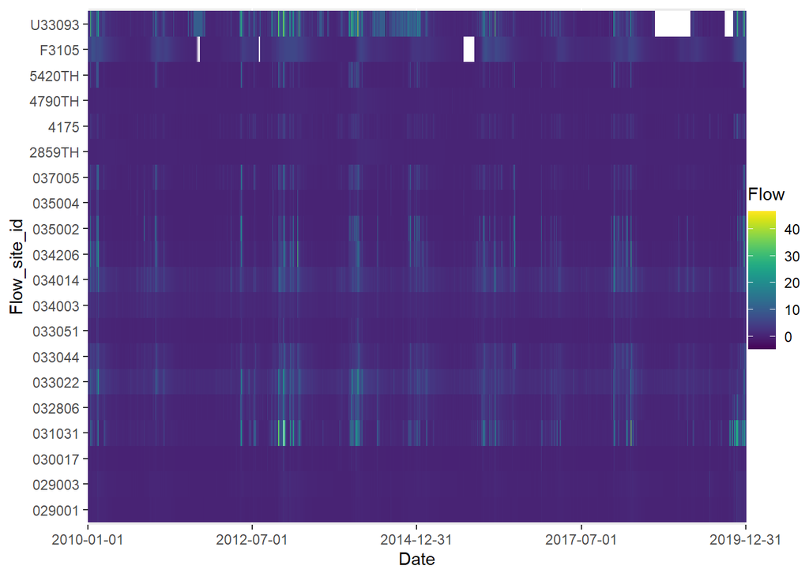

```r
# generate a heatmap of mean daily flows
a <- plot_heatmap(data = flow_data, x = "date", y = "flow_site_id", fill = "flow",
    dual = FALSE)
# view heatmap
gridExtra::grid.arrange(a[[1]])
```

```r
# view table of completeness statistics for each site
a[[3]]
```

| y | missing | total | prop_missing | number_of_gaps | smallest_gap | biggest_gap |
| --- | --- | --- | --- | --- | --- | --- |
| 029001 | 0 | 3652 | 0.0000000000 | NA | NA | NA |
| 029003 | 0 | 3652 | 0.0000000000 | NA | NA | NA |
| 030017 | 0 | 3652 | 0.0000000000 | NA | NA | NA |
| 031031 | 4 | 3652 | 0.0010952903 | 2 | 1 | 3 |
| 032806 | 1 | 3652 | 0.0002738226 | 1 | 1 | 1 |
| 033022 | 0 | 3652 | 0.0000000000 | NA | NA | NA |
| 033044 | 0 | 3652 | 0.0000000000 | NA | NA | NA |
| 033051 | 0 | 3652 | 0.0000000000 | NA | NA | NA |
| 034003 | 0 | 3652 | 0.0000000000 | NA | NA | NA |
| 034014 | 0 | 3652 | 0.0000000000 | NA | NA | NA |

[output cut: 10 more lines]

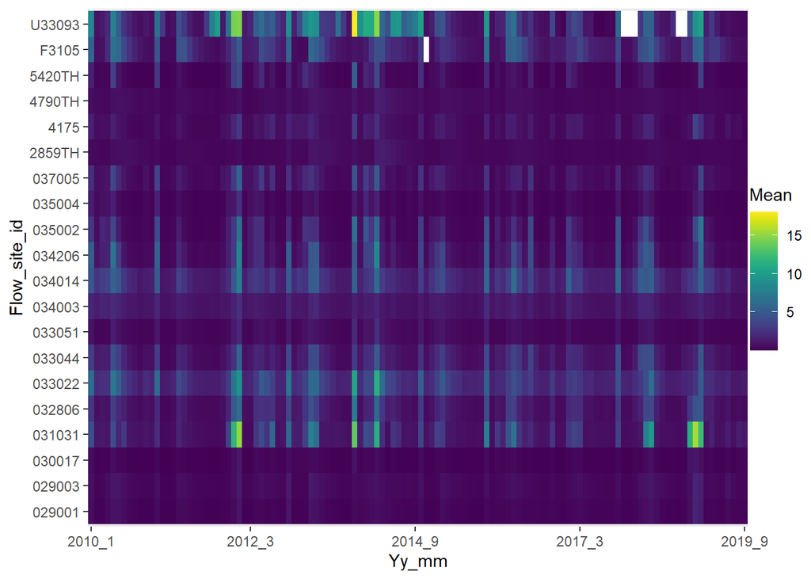

```r
# uses flow_data, as produced using import_flow()
flow_data$month <- lubridate::month(flow_data$date)
flow_data$year <- lubridate::year(flow_data$date)
temp1 <- flow_data %>%
    dplyr::group_by(month, year, flow_site_id) %>%
    dplyr::summarise(across(.cols = "flow", list(mean = ~mean(flow, na.rm = TRUE),
        missing = ~length(which(is.na(flow))), total = ~length(flow), perc_missing = ~(length(which(is.na(flow)))/length(flow)) *
            100), .names = "{.fn}"))
temp1$yy_mm <- paste(temp1$year, temp1$month, sep = "_")

# heatmap of monthly mean flows.
a <- plot_heatmap(data = temp1, x = "yy_mm", y = "flow_site_id", fill = "mean", dual = FALSE)
# view heatmap
gridExtra::grid.arrange(a[[1]])
```

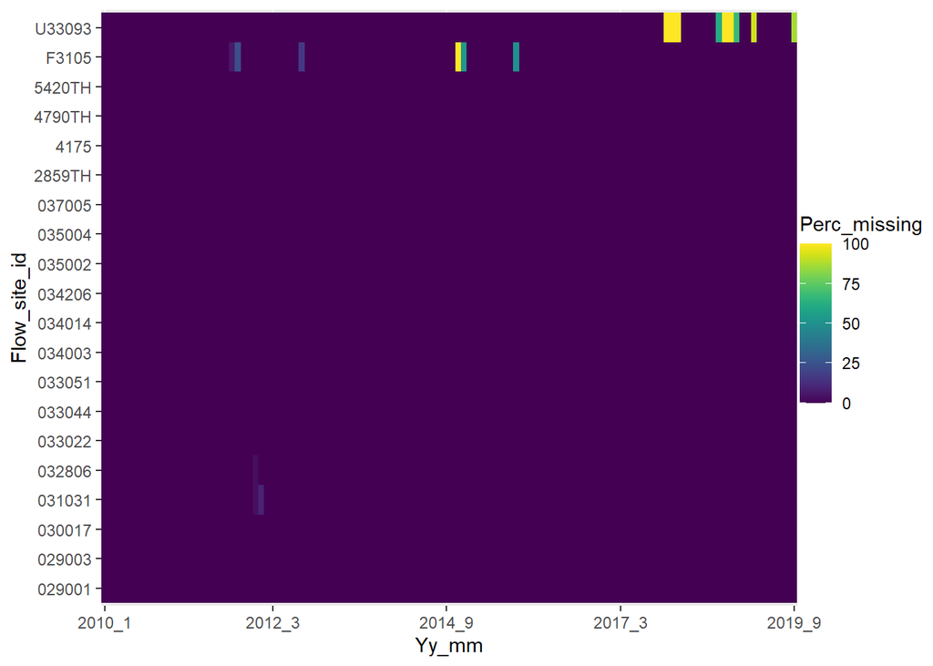

```r
# heatmap of monthly percentage completeness of the daily flow data
a <- plot_heatmap(data = temp1, x = "yy_mm", y = "flow_site_id", fill = "perc_missing")
# view heatmap
gridExtra::grid.arrange(a[[1]])
```

## Calculate flow statistics

`calc_flowstats` uses a time series of measured or modelled flows to calculate a suite of long-term and seasonal (winter and summer) flow statistics for one or more sites (stations).

It is primarily designed to work with mean daily flows (e.g. as produced by import_flow), but can also be applied to time series data on a longer (e.g. monthly) time step.

Regardless, the data should be regularly spaced and the same time step should be used for all sites.

```r
# uses flow_data, as produced using import_flow()

# set any negative flow readings to NA
flow_data$flow[flow_data$flow <= 0] <- NA

# calculate flow statistics
flow_stats <- calc_flowstats(data = flow_data, site_col = "flow_site_id", date_col = "date",
    flow_col = "flow")
```

`calc_flowstats` returns a list of two data frames. The first contains a suite of time-varying flow statistics for every 6 month winter/summer period at every site. See `?calc_flowstats` for definitions of these statistics.

```r
# view time-varying flow statistics
flow_stats[[1]]
```

|  | flow_site_id | season | water_year | Q10mean | Q10sd | Q10z | Q30mean | Q30sd | Q30z | Q50mean | Q50sd | Q50z | Q70mean | Q70sd | Q70z | Q95mean | Q95sd | Q95z | Q10 | Q30 | Q50 | Q70 | Q90 | Q95 | Q99 | zero | mean | sd | lsd | … |
| --- | --- | --- | --- | --- | --- | --- | --- | --- | --- | --- | --- | --- | --- | --- | --- | --- | --- | --- | --- | --- | --- | --- | --- | --- | --- | --- | --- | --- | --- | --- |
| 1 | 029001 | Summer | 2009 | 0.3819200 | 0.1596622 | 1.0539749915 | 0.2200200 | 0.08652673 | -0.550350160 | 0.1418000 | 0.02940446 | -1.217502411 | 0.11446000 | 0.03147133 | -1.202999514 | 0.08765000 | 0.024895080 | -9.459701e-01 | 0.5502 | 0.1724 | 0.1060 | 0.0766 | 0.0680 | 0.06410 | 0.05600 | 0 | 0.18265574 | 0.16818575 | 0.71660178 | … |
| 2 | 029001 | Summer | 2010 | 0.3819200 | 0.1596622 | -0.7523382219 | 0.2200200 | 0.08652673 | -0.943292315 | 0.1418000 | 0.02940446 | -1.251510858 | 0.11446000 | 0.03147133 | -1.234774462 | 0.08765000 | 0.024895080 | -1.592684e+00 | 0.2618 | 0.1384 | 0.1050 | 0.0756 | 0.0502 | 0.04800 | 0.04400 | 0 | 0.12947541 | 0.08503043 | 0.58895684 | … |
| 3 | 029001 | Summer | 2011 | 0.3819200 | 0.1596622 | -0.3865660594 | 0.2200200 | 0.08652673 | -0.138916609 | 0.1418000 | 0.02940446 | 0.959038212 | 0.11446000 | 0.03147133 | 1.275446395 | 0.08765000 | 0.024895080 | 9.821218e-01 | 0.3202 | 0.2080 | 0.1700 | 0.1546 | 0.1194 | 0.11210 | 0.09858 | 0 | 0.20485246 | 0.11993888 | 0.39250722 | … |
| 4 | 029001 | Summer | 2012 | 0.3819200 | 0.1596622 | -0.0759102502 | 0.2200200 | 0.08652673 | -0.145850882 | 0.1418000 | 0.02940446 | -0.435308125 | 0.11446000 | 0.03147133 | -0.789925196 | 0.08765000 | 0.024895080 | -9.499869e-01 | 0.3698 | 0.2074 | 0.1290 | 0.0896 | 0.0652 | 0.06400 | 0.06182 | 0 | 0.18388525 | 0.15561630 | 0.67624065 | … |
| 5 | 029001 | Summer | 2013 | 0.3819200 | 0.1596622 | -0.0370782740 | 0.2200200 | 0.08652673 | 0.420448106 | 0.1418000 | 0.02940446 | 0.516928398 | 0.11446000 | 0.03147133 | 0.576397549 | 0.08765000 | 0.024895080 | 7.772620e-01 | 0.3760 | 0.2564 | 0.1570 | 0.1326 | 0.1132 | 0.10700 | 0.10082 | 0 | 0.21454098 | 0.13498167 | 0.48705318 | … |
| 6 | 029001 | Summer | 2014 | 0.3819200 | 0.1596622 | -1.0178988330 | 0.2200200 | 0.08652673 | -0.781492604 | 0.1418000 | 0.02940446 | -1.149485517 | 0.11446000 | 0.03147133 | -0.726375301 | 0.08765000 | 0.024895080 | -5.764191e-01 | 0.2194 | 0.1524 | 0.1080 | 0.0916 | 0.0800 | 0.07330 | 0.06582 | 0 | 0.13377596 | 0.06132062 | 0.40734985 | … |
| 7 | 029001 | Summer | 2015 | 0.3819200 | 0.1596622 | -0.4504509234 | 0.2200200 | 0.08652673 | 0.200862784 | 0.1418000 | 0.02940446 | 1.605198710 | 0.11446000 | 0.03147133 | 1.180121552 | 0.08765000 | 0.024895080 | 1.058442e+00 | 0.3100 | 0.2374 | 0.1890 | 0.1516 | 0.1182 | 0.11400 | 0.09600 | 0 | 0.20563934 | 0.08199813 | 0.37617577 | … |
| 8 | 029001 | Summer | 2016 | 0.3819200 | 0.1596622 | -0.7222747565 | 0.2200200 | 0.08652673 | -0.323830564 | 0.1418000 | 0.02940446 | 0.516928398 | 0.11446000 | 0.03147133 | 0.608172496 | 0.08765000 | 0.024895080 | 5.362505e-01 | 0.2666 | 0.1920 | 0.1570 | 0.1336 | 0.1082 | 0.10100 | 0.09546 | 0 | 0.17486339 | 0.07015390 | 0.34482311 | … |
| 9 | 029001 | Summer | 2017 | 0.3819200 | 0.1596622 | 2.3241564050 | 0.2200200 | 0.08652673 | 2.593187081 | 0.1418000 | 0.02940446 | -0.163240547 | 0.11446000 | 0.03147133 | -0.586565532 | 0.08765000 | 0.024895080 | -3.876268e-01 | 0.7530 | 0.4444 | 0.1370 | 0.0960 | 0.0800 | 0.07800 | 0.06920 | 0 | 0.31446995 | 0.30472479 | 0.90905218 | … |
| 10 | 029001 | Summer | 2018 | 0.3819200 | 0.1596622 | 0.0643859218 | 0.2200200 | 0.08652673 | -0.330764838 | 0.1418000 | 0.02940446 | 0.618953740 | 0.11446000 | 0.03147133 | 0.900502014 | 0.08765000 | 0.024895080 | 1.098611e+00 | 0.3922 | 0.1914 | 0.1600 | 0.1428 | 0.1190 | 0.11500 | 0.10582 | 0 | 0.21913115 | 0.20354583 | 0.48763006 | … |

[output cut: 370 more lines]

The second data table contains long-term flow statistics. The data are arranged in long format, with the following columns:

```r
# view long-term flow statistics
flow_stats[[2]]
```

| season | value | parameter | flow_site_id |
| --- | --- | --- | --- |
| Summer | 0.381920000 | Q10mean | 029001 |
| Winter | 0.513944444 | Q10mean | 029001 |
| Summer | 0.220020000 | Q30mean | 029001 |
| Winter | 0.406944444 | Q30mean | 029001 |
| Summer | 0.141800000 | Q50mean | 029001 |
| Winter | 0.315777778 | Q50mean | 029001 |
| Summer | 0.114460000 | Q70mean | 029001 |
| Winter | 0.210822222 | Q70mean | 029001 |
| Summer | 0.087650000 | Q95mean | 029001 |
| Winter | 0.099977778 | Q95mean | 029001 |

[output cut: 2390 more lines]

## Join biology and flow data

The `join_he` function links biology data to six-monthly flow statistics (from calc_flowstats) to create a dataset for hydro-ecological modelling. The function includes an option to lag selected flow statistics.

We will join the data for the pairs of biology and flow sites specified in `master_data`.

```r
# get output from calc_flowstats
flowstats_1 <- flow_stats[[1]]

# create two-column table mapping biology sites to flow sites
mapping <- master_data[, c("biol_site_id", "flow_site_id")]

# join flow statistics to biology data

join_data <- join_he(biol_data = biol_all, flow_stats = flowstats_1, mapping = mapping,
    lag_vars = c("Q95z", "Q10z"), LS1 = TRUE, LS2 = TRUE)

# view join_data
join_data
```